# Exercise 5_2: Raster cube with stars

Advanced Geospatial Data Processing for Social Scientists

Author

Dennis Abel & Stefan Jünger

### Exercises

We are deliberately boring in this exercise - we want to do exactly the same as before - this time with `stars`. Our aim is to create a raster cube (`stars`) for Texas population data between 2017 and 2020.

**🏋 Exercise 1**

Load the four population raster layers for Texas 2017-2020 (`./data/US-TX_ppp_2017_1km.tif`-`./data/US-TX_ppp_2020_1km.tif`) with `stars::read_stars()` and integrate these into one raster cube. First, create a file list for all four raster layers. Second, prepare a vector which stores the four years. Finally, you can read in the file list along the list of years.

**🏋 Exercise 2**

Adjust the attribute name (`names()`) to a meaningful string for your variable.

**🏋 Exercise 3**

Again, let’s reproject our Texas data to EPSG:3081. Inspect the object afterwards (`print()`).

**🏋 Exercise 4**

Visualize all four years with a spatial window of `x = 0:1000` and `y = 0:1000`. You can input your `stars` object into base `R` `plot()` command. The default color scale is often insufficient. Specify the argument `breaks = "equal"` to improve readability.

**🏋 Exercise 5**

Store your `stars` object as `.rds` file on disk (`saveRDS`).

### Solutions

**✅ Solution 1**

```r
library(dplyr)
library(stars)

# Load the raster data
files <- list.files("./data", pattern = "US-TX_ppp_20(17|18|19|20)_1km\\.tif$", full.names = TRUE)

# Vector of years
dates <- 2017:2020

# Read layers along time dimension
TX_pop_cube <- read_stars(files, along = list(time = dates))

print(TX_pop_cube)
```

```
stars object with 3 dimensions and 1 attribute
attribute(s), summary of first 1e+05 cells:
                        Min. 1st Qu.     Median     Mean   3rd Qu.     Max.
US-TX_ppp_2017_1km.tif     0       0 0.02900932 1.783346 0.1573603 1113.042
                         NA's
US-TX_ppp_2017_1km.tif  76662
dimension(s):
     from   to offset     delta refsys point x/y
x       1 1575 -106.6  0.008333 WGS 84 FALSE [x]
y       1 1279   36.5 -0.008333 WGS 84 FALSE [y]
time    1    4   2017         1     NA    NA
```

**✅ Solution 2**

```r
names(TX_pop_cube) <- "population"

st_dimensions(TX_pop_cube)
```

```
     from   to offset     delta refsys point x/y
x       1 1575 -106.6  0.008333 WGS 84 FALSE [x]
y       1 1279   36.5 -0.008333 WGS 84 FALSE [y]
time    1    4   2017         1     NA    NA
```

```r
print(TX_pop_cube)
```

```
stars object with 3 dimensions and 1 attribute
attribute(s), summary of first 1e+05 cells:
            Min. 1st Qu.     Median     Mean   3rd Qu.     Max.  NA's
population     0       0 0.02900932 1.783346 0.1573603 1113.042 76662
dimension(s):
     from   to offset     delta refsys point x/y
x       1 1575 -106.6  0.008333 WGS 84 FALSE [x]
y       1 1279   36.5 -0.008333 WGS 84 FALSE [y]
time    1    4   2017         1     NA    NA
```

**✅ Solution 3**

```r
grid <- st_bbox(TX_pop_cube) |>
  st_as_sfc() |>
  st_transform(crs = 3081) |>
  st_bbox() |>
  st_as_stars(nx = dim(TX_pop_cube)["x"],
              ny = dim(TX_pop_cube)["y"])

TX_pop_cube <- st_warp(TX_pop_cube, grid)

print(TX_pop_cube)
```

```
stars object with 3 dimensions and 1 attribute
attribute(s), summary of first 1e+05 cells:
            Min. 1st Qu.     Median     Mean  3rd Qu.     Max.  NA's
population     0       0 0.03388117 1.545083 0.164228 1113.042 84966
dimension(s):
     from   to  offset  delta                       refsys x/y
x       1 1575  333015  836.7 NAD83 / Texas State Mappi... [x]
y       1 1279 1609018 -922.4 NAD83 / Texas State Mappi... [y]
time    1    4    2017      1                           NA
```

**✅ Solution 4**

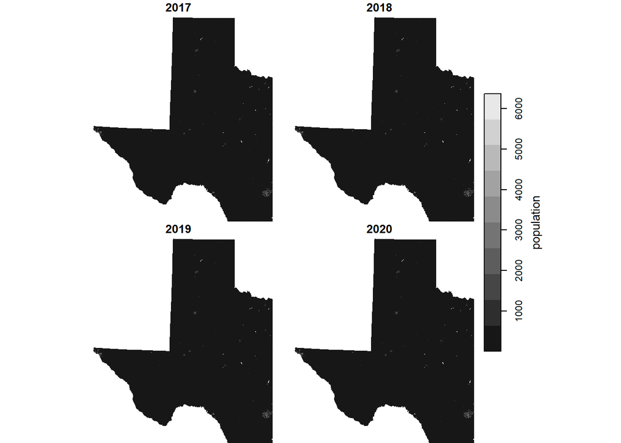

```r
# Plot a single layer
plot(TX_pop_cube[1,
                 0:1000,
                 0:1000,
                 1:4],
     breaks = "equal")
```

**✅ Solution 5**

```r
# Export
saveRDS(TX_pop_cube, "./data/CA_pop_cube.rds")
```